# P3_Kyuri

Kyuri Park

September 16, 2022

```r
library(tidyverse)
library(magrittr)
library(mice)
library(DAAG)
```

## 1. Create a histogram of the variable `age` using the function `geom_histogram()`.

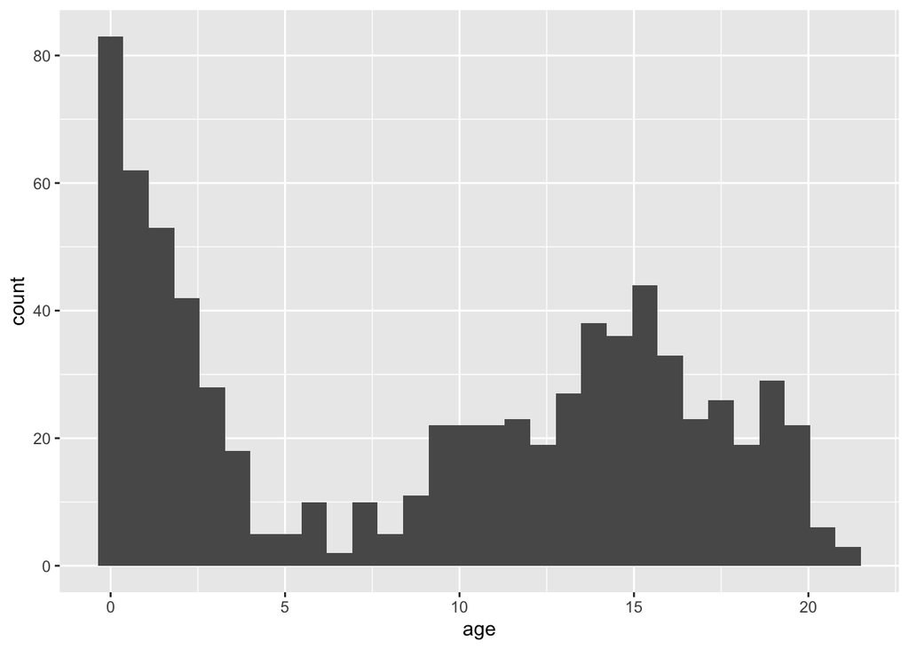

```r
boys %>%  ggplot(aes(x=age)) +
  geom_histogram()
```

## 2. Create a bar chart of the variable `gen` using the function `geom_bar()`.

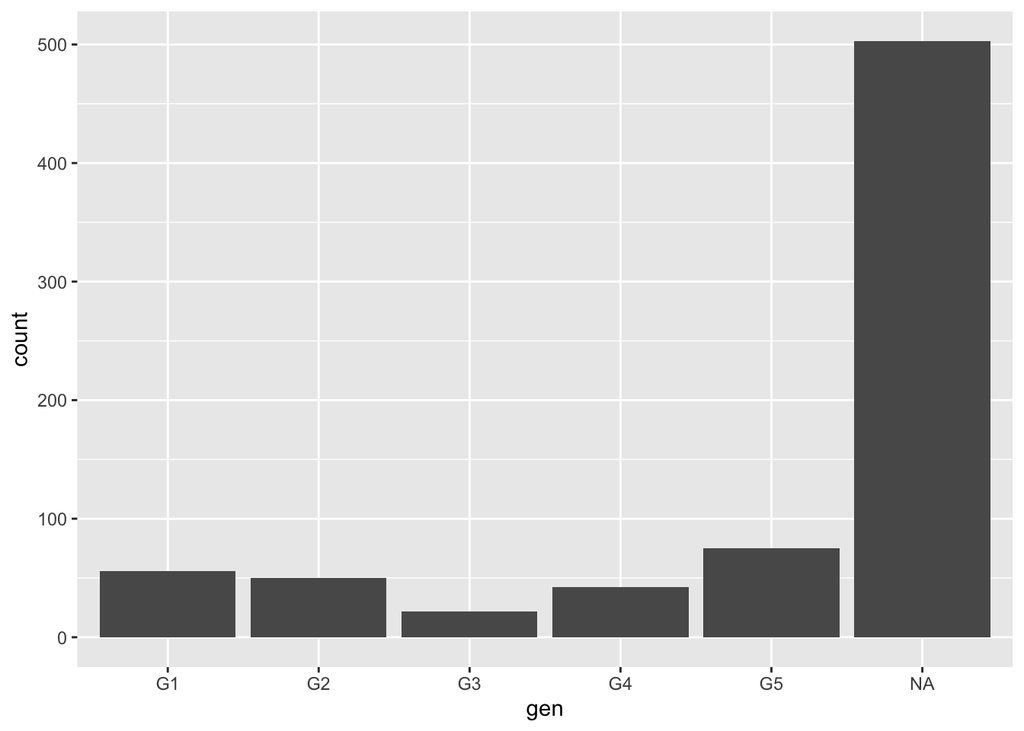

```r
boys %>% ggplot(aes(x=gen)) +
  geom_bar()
```

## 3. Create a missingness indicator for the variables `gen`, `phb` and `tv`.

```r
boys <- boys %>%
  mutate(gen_ind = is.na(gen),
         phb_ind = is.na(phb),
         tv_ind = is.na(tv))
```

## 4. Assess whether missingness in the variables `gen`, `phb` and `tv` is related to someones age.

As seen below, it is observed that the average age is largely different for those who have missing values on `gen`, `phb` and `tv`.

```r
vars <- c("gen_ind", "phb_ind", "tv_ind")

summaries <- list()
for (i in vars){
  summaries[[i]] <- boys %>%
    group_by(value = .data[[i]]) %>%
    summarize(avg.age = mean(age))}

pander::pander(summaries)
```

- **gen_ind**:

  | value | avg.age |
  | --- | --- |
  | FALSE | 14.03 |
  | TRUE | 6.787 |

- **phb_ind**:

  | value | avg.age |
  | --- | --- |
  | FALSE | 14.03 |
  | TRUE | 6.788 |

- **tv_ind**:

  | value | avg.age |
  | --- | --- |
  | FALSE | 14.09 |
  | TRUE | 7.025 |

## 5. Create a histogram for the variable `age`, faceted by whether or not someone has a missing value on `gen`.

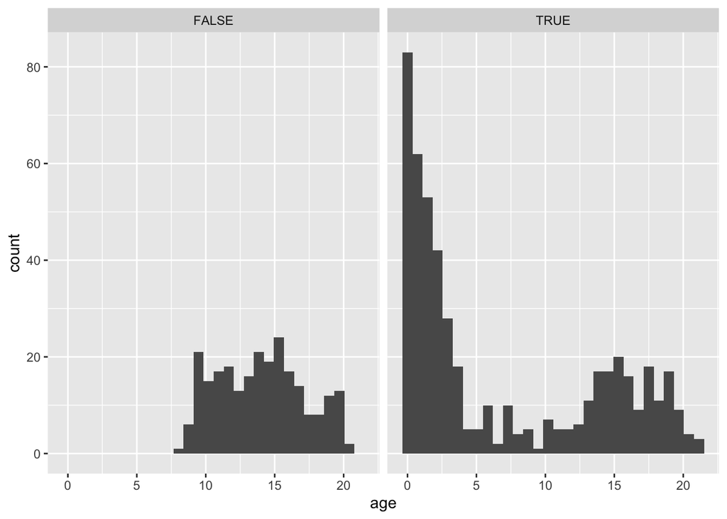

```r
boys %>% ggplot(aes(x=age)) +
  geom_histogram()+
  facet_wrap(~gen_ind)
```

## 6. Create a scatterplot with `age` on the x-axis and `bmi` on the y-axis, using the function `geom_point()`.

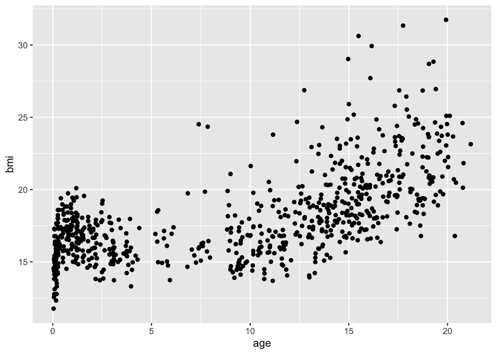

```r
boys %>% ggplot(aes(x=age, y=bmi)) +
  geom_point()
```

## 7. Add a colour aesthetic to the previous plot using the missingness indicator of the variable `gen`.

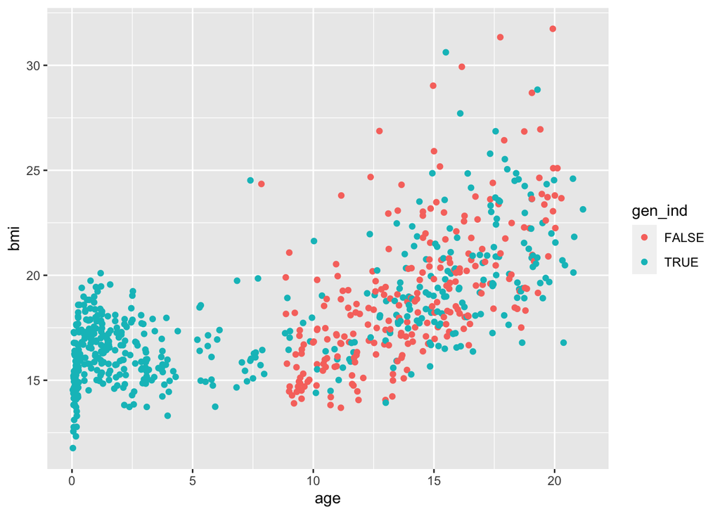

```r
boys %>% ggplot(aes(x=age, y=bmi, color=gen_ind)) +
  geom_point()
```

## 8. Visualize the relationship between `reg` (region) and `age` using a boxplot.

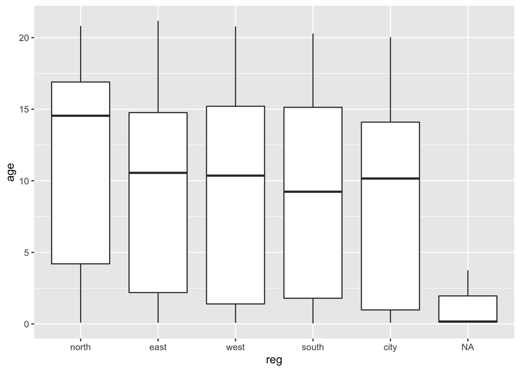

```r
boys %>% ggplot(aes(x = reg, y = age)) +
  geom_boxplot()
```

## 9. Create a density plot of age, splitting the densities by `gen` using the `fill` aesthetic.

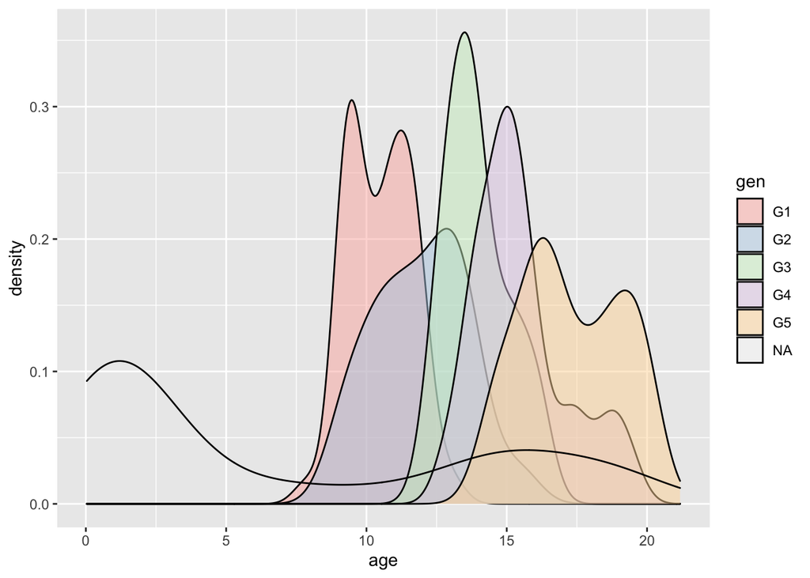

```r
boys %>% ggplot(aes(x=age, fill = gen)) +
  geom_density(alpha= 0.5) +
  scale_fill_brewer(palette = "Pastel1")
```

## 10. Create a diverging bar chart for `hgt` in the `boys` data set, that displays for every `age` year that year’s mean height in deviations from the overall average `hgt`.

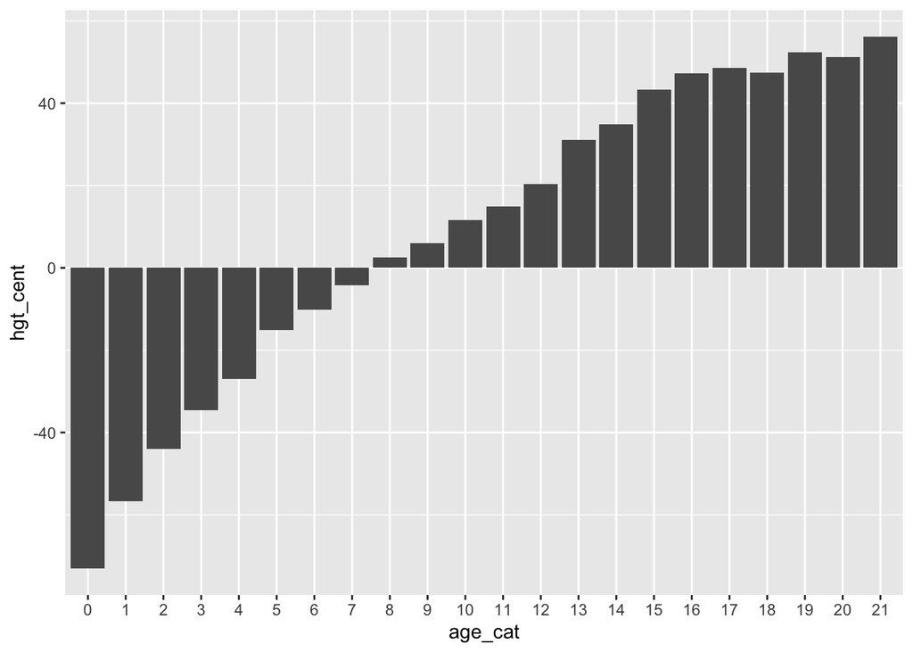

```r
boys %>%
  mutate(age_cat = as.factor(round(age)),
         hgt_cent = scale(hgt, scale=FALSE)) %>%
  filter(!is.na(hgt_cent)) %>%
  group_by(age_cat) %>%
  summarize(hgt_cent = mean(hgt_cent)) %>%
  ggplot(aes(x = age_cat, y = hgt_cent)) +
  geom_col()
```

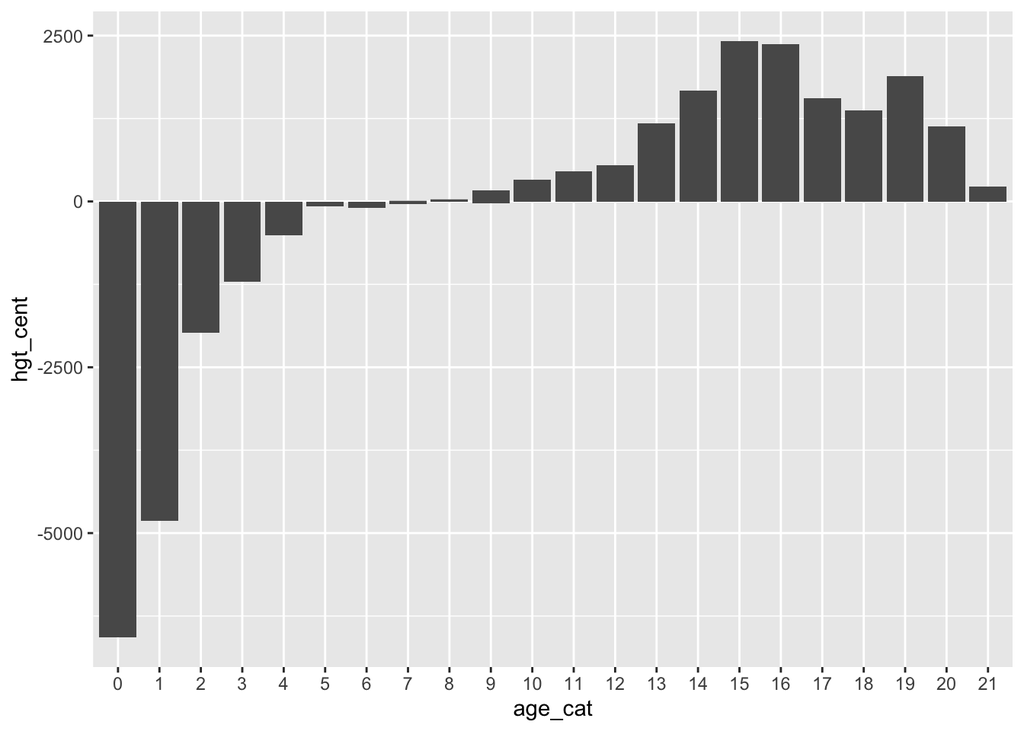

```r
# what does this plot represent? And how the summarzie works here? Felt like mutate() should've been used
boys %>%
  mutate(age_cat = as.factor(round(age)),
         hgt_cent = scale(hgt, scale=FALSE)) %>%
  filter(!is.na(hgt_cent)) %>%
  ## these two lines...
  # group_by(age_cat) %>%
  # summarize(hgt_cent = mean(hgt_cent)) %>%
  ggplot(aes(x = age_cat, y = hgt_cent)) +
  geom_col()
```

## 11. Load the data `elastic1` and `elastic2` and bind the data frames together using the function `bind_rows()` and add a grouping variable indicating whether an observation comes from `elastic1` or from `elastic2`.

```r
elastic <- bind_rows(list("elastic1" = elastic1, "elastic2" = elastic2), .id = "group") %>% remove_rownames()
elastic
```

| group | stretch | distance |
| --- | --- | --- |
| elastic1 | 46 | 183 |
| elastic1 | 54 | 217 |
| elastic1 | 48 | 189 |
| elastic1 | 50 | 208 |
| elastic1 | 44 | 178 |
| elastic1 | 42 | 150 |
| elastic1 | 52 | 249 |
| elastic2 | 30 | 71 |
| elastic2 | 50 | 196 |
| elastic2 | 40 | 127 |

[output cut: 6 more lines]

## 12. Create a scatterplot mapping `stretch` on the x-axis and `distance` on the y-axis, and map the just created group indicator as the color aesthetic.

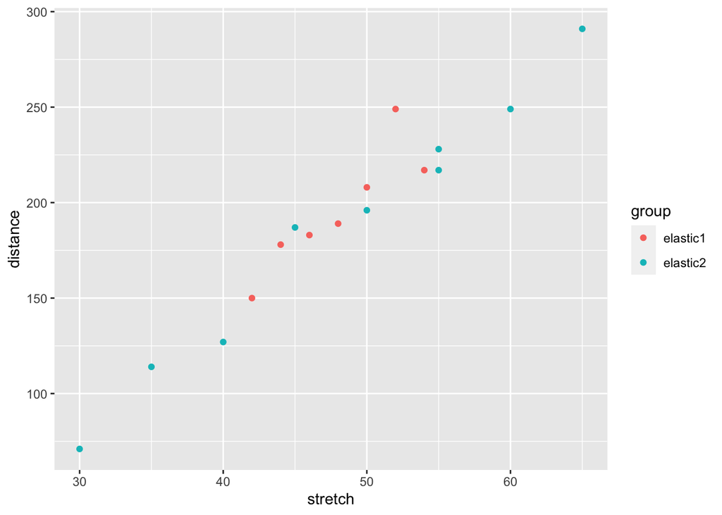

```r
elastic %>%
  ggplot(aes(x = stretch, y = distance, color = group)) +
  geom_point()
```

## 13. Recreate the previous plot, but now assess whether the results of the two data sets appear consistent by adding a linear regression line.

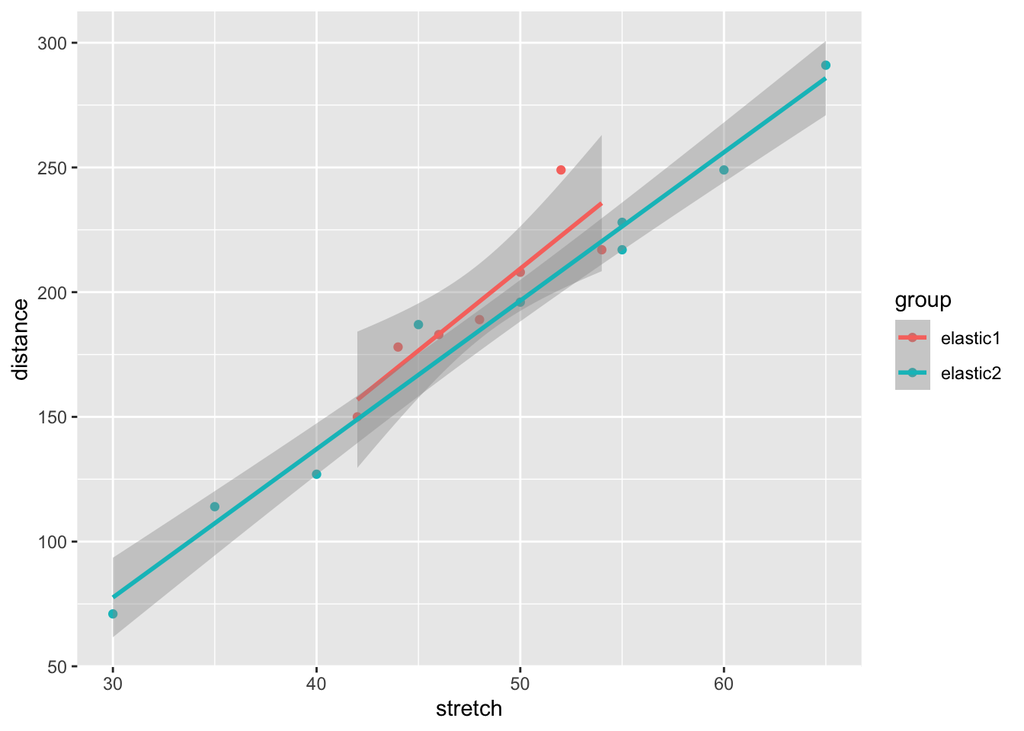

```r
elastic %>%
  ggplot(aes(x = stretch, y = distance, color = group)) +
  geom_point() +
  geom_smooth(method = "lm")
```

## 14. For each of the data sets `elastic1` and `elastic2`, fit a regression model with `y = distance` on `x = stretch` using `lm(y ~ x, data)`.

```r
elastic %>%
  split(.$group) %>%
  map(~ lm(distance ~ stretch, data = .x)) %>%
  map(summary)
```

```
$elastic1

Call:
lm(formula = distance ~ stretch, data = .x)

Residuals:
       1        2        3        4        5        6        7
 -0.1429 -18.7143  -7.2857  -1.4286   8.0000  -6.8571  26.4286

Coefficients:
            Estimate Std. Error t value Pr(>|t|)
(Intercept) -119.143     70.943  -1.679  0.15391
stretch        6.571      1.473   4.462  0.00663 **
---
Signif. codes:  0 '***' 0.001 '**' 0.01 '*' 0.05 '.' 0.1 ' ' 1

Residual standard error: 15.59 on 5 degrees of freedom
Multiple R-squared:  0.7992,    Adjusted R-squared:  0.7591
F-statistic: 19.91 on 1 and 5 DF,  p-value: 0.006631


$elastic2

Call:
lm(formula = distance ~ stretch, data = .x)

Residuals:
     Min       1Q   Median       3Q      Max
-10.0833  -7.0833  -0.5833   5.1667  20.1667

Coefficients:
             Estimate Std. Error t value Pr(>|t|)
(Intercept) -100.9167    15.6102  -6.465 0.000345 ***
stretch        5.9500     0.3148  18.899 2.89e-07 ***
---
Signif. codes:  0 '***' 0.001 '**' 0.01 '*' 0.05 '.' 0.1 ' ' 1

Residual standard error: 10.44 on 7 degrees of freedom
Multiple R-squared:  0.9808,    Adjusted R-squared:  0.978
F-statistic: 357.2 on 1 and 7 DF,  p-value: 2.888e-07
```

## 15. For both of the previously created fitted models, determine the fitted values and the standard errors of the fitted values, and the proportion explained variance $R^2$.

```r
res <- elastic %>%
  split(.$group) %>%
  map(~ lm(distance ~ stretch, data = .x)) %>%
  map(~ list(fitted_values = predict(., se.fit=T)$fit,
             se_fitted = predict(., se.fit=T)$se.fit,
             R2 = summary(.)$r.squared))

pander::pander(res)
```

- **elastic1**:
  - **fitted_values**:

    | 1 | 2 | 3 | 4 | 5 | 6 | 7 |
    | --- | --- | --- | --- | --- | --- | --- |
    | 183.1 | 235.7 | 196.3 | 209.4 | 170 | 156.9 | 222.6 |

  - **se_fitted**: *6.587*, *10.62*, *5.892*, *6.587*, *8.332*, *10.62* and *8.332*
  - **R2**: *0.7992*
- **elastic2**:
  - **fitted_values**:

    | 8 | 9 | 10 | 11 | 12 | 13 | 14 | 15 | 16 |
    | --- | --- | --- | --- | --- | --- | --- | --- | --- |
    | 77.58 | 196.6 | 137.1 | 166.8 | 256.1 | 226.3 | 107.3 | 226.3 | 285.8 |

  - **se_fitted**: *6.74*, *3.52*, *4.359*, *3.635*, *5.06*, *4.065*, *5.453*, *4.065* and *6.297*
  - **R2**: *0.9808*

## 16. Study the residual versus leverage plots for both models.

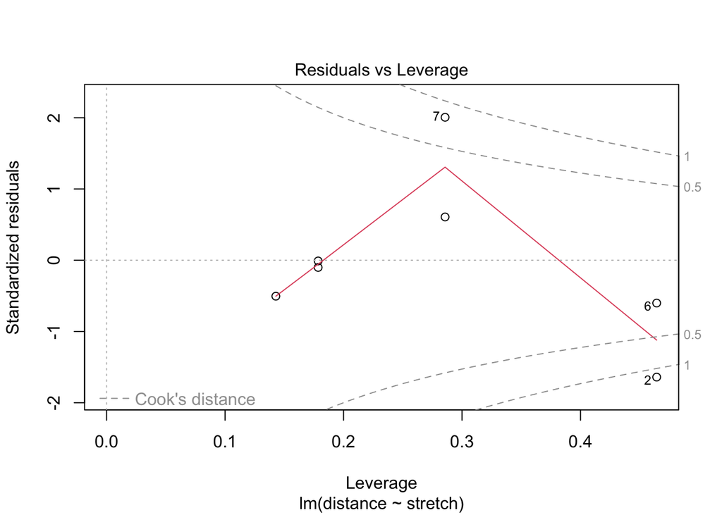

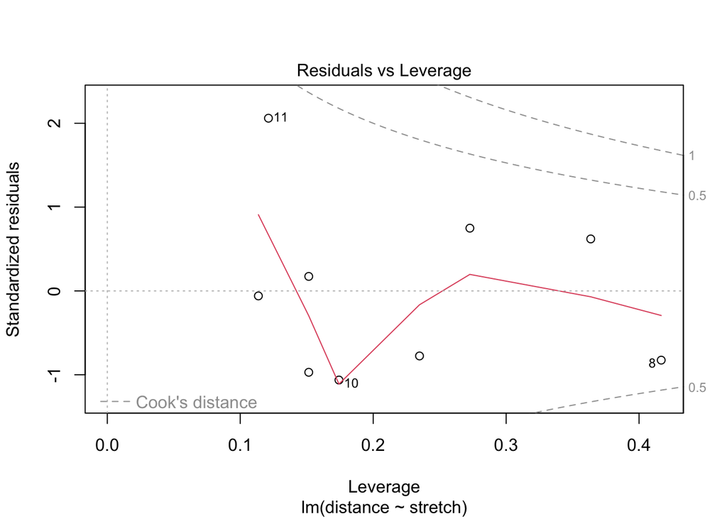

```r
elastic %>%
  split(.$group) %>%
  map(~ lm(distance ~ stretch, data = .x)) %>%
  map(~plot(., which=5))
```